# 十一周新聞作業

TING

2025-05-09

# 大專校院環境相關科系(所)教師人數

資料範圍：2008–2024，台灣本島所有縣市行政區 href：https://www.gender.ey.gov.tw/gecdb/Stat_Statistics_Query.aspx?sn=Q35gsibXbGz4bGJ0y5epyg%40%40&statsn=Ryc4qEyv%246QZ7UyL3mrDvA%40%40&d=m9ww9odNZAz2Rc5Ooj%24wIQ%40%40

def：女性環境相關科系(所)教師占比

cat1：環境、能源與科技

cat2：環境、能源與科技之教育

複分類：環境、能源與科技領域教師

### 清理資料

```r
raw <- read_excel("D:/200學業/210.1新聞所/新聞資訊分析資料/第十二周作業/大專校院環境相關科系(所)教師人數-20250509_xlsx.xlsx", skip = 2, col_names = FALSE)
#先整理資料，表格超亂

# 設定欄名：第 2 列是性別，第 3 列是設立別
gender_row <- as.character(raw[2, ])
school_row <- as.character(raw[3, ])

# 把 NA 補成空字串
gender_row[is.na(gender_row)] <- ""
school_row[is.na(school_row)] <- ""

# 合併為欄名
colnames(raw) <- make.unique(paste0(gender_row, "_", school_row))

# 保留第 5 列（97 學年度）以後的資料
data <- raw[-c(1:4), ] #也順便接受raw的欄位

# 加入年份欄位（從 97 學年度開始） 後面的補充也不要了

# 保留第 5～21 列（共 17 年）
data <- raw %>%
  slice(5:21) %>%
  mutate(year = 97:113 + 1911)

#發現最後一行也怪怪
data <- data[1:16, ]

# 整成 tidy 格式
data_long <- data %>%
  pivot_longer(cols = -year, names_to = "group", values_to = "count") %>%
  separate(group, into = c("gender", "school_type"), sep = "_") %>%
  mutate(count = as.numeric(count))
#把gender的na補上

data_long <- data_long %>%
  mutate(gender = na_if(gender, "")) %>%  # 把空字串變成 NA
  fill(gender, .direction = "down")       # 再往下填補 NA
```

### 接著畫折線圖

```r
library(showtext)
```

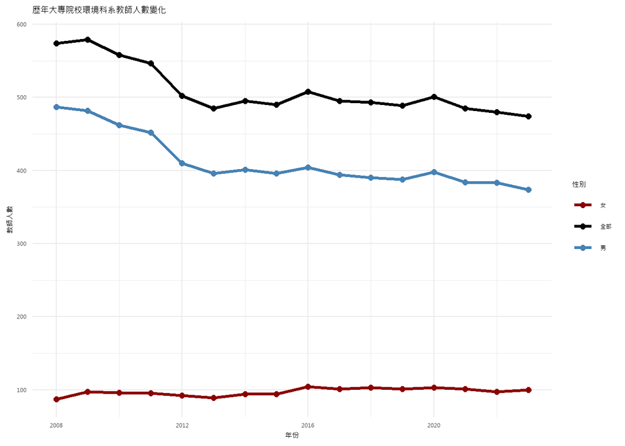

```r
library(ggplot2)
library(stringr)

# 啟用中文字型支援（微軟正黑體）
font_add("cw", "msjh.ttc")  # Windows 通常可用
showtext_auto()

# 整理資料
plot_data <- data_long %>%
  filter(school_type == "總計") %>%
  group_by(year, gender) %>%
  summarise(total = sum(count, na.rm = TRUE), .groups = "drop")

total_line <- plot_data %>%
  group_by(year) %>%
  summarise(total = sum(total), .groups = "drop") %>%
  mutate(gender = "全部")

# 合併並處理全形空格
plot_all <- bind_rows(plot_data, total_line) %>%
  mutate(
    gender = str_replace_all(gender, "\u3000", ""),
    gender = trimws(as.character(gender))
  )

# 畫圖物件（指定中文字型）
p <- ggplot(plot_all, aes(x = year, y = total, color = gender)) +
  geom_line(size = 1.2) +
  geom_point(size = 2) +
  scale_color_manual(values = c("男" = "steelblue", "女" = "darkred", "全部" = "black")) +
  labs(title = "歷年大專院校環境科系教師人數變化",
       x = "年份", y = "教師人數", color = "性別") +
  theme_minimal(base_family = "cw")  # 中文字型設定
print(p)
```

```r
# 儲存 PDF 圖檔
ggsave("D:\\200學業\\210.1新聞所\\新聞資訊分析資料\\第十二周作業\\教師人數變化圖.pdf",
       plot = p, device = cairo_pdf, width = 8, height = 5, dpi = 300)
```

### 清理資料計算公私立男女比

```r
library(stringr)

#處理掉全部的空格
data_clean <- data_long %>%
  mutate(
    gender = str_replace_all(gender, "\u3000", ""),           # 去掉全形空格
    gender = trimws(gender),                                  # 去掉左右空白
    school_type = str_replace_all(school_type, "\u3000", ""), # 處理 school_type 的全形空格
    school_type = trimws(school_type),                        # 處理左右空白
    school_type = str_replace(school_type, "\\.1$", "")       # 去掉 .1
  )

# 計算每年每 school_type 的男女總數
gender_by_type <- data_clean %>%
  filter(school_type %in% c("公立", "私立")) %>%
  group_by(year, school_type, gender) %>%
  summarise(total = sum(count, na.rm = TRUE), .groups = "drop")

# 轉寬格式（欄位變成男、女）
gender_wide <- gender_by_type %>%
  pivot_wider(names_from = gender, values_from = total)

# 計算女性占比
gender_ratio_by_type <- gender_wide %>%
  mutate(
    female_ratio = 女 / (男 + 女)
  )
```

### 畫折線圖

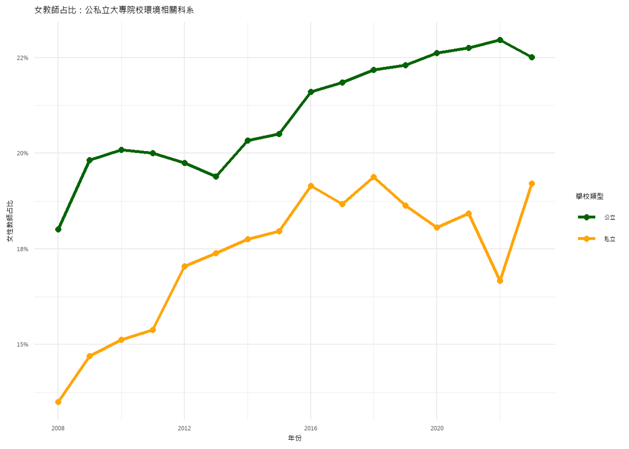

```r
library(ggplot2)
library(showtext)


# 中文支援：微軟正黑體
font_add("cw", "msjh.ttc")
showtext_auto()

# 畫圖物件
p2 <- ggplot(gender_ratio_by_type, aes(x = year, y = female_ratio, color = school_type)) +
  geom_line(size = 1.2) +
  geom_point(size = 2) +
  scale_color_manual(values = c("公立" = "darkgreen", "私立" = "orange")) +
  scale_y_continuous(labels = scales::percent_format(accuracy = 1)) +
  labs(
    title = "女教師占比：公私立大專院校環境相關科系",
    x = "年份", y = "女性教師占比", color = "學校類型"
  ) +
  theme_minimal(base_family = "cw")


print(p2)
```

```r
ggsave("D:\\200學業\\210.1新聞所\\新聞資訊分析資料\\第十二周作業\\女教師占比_公私立比較.pdf",
       plot = p2, device = cairo_pdf, width = 8, height = 5, dpi = 300)
```

### 清理地圖準備接地圖

```r
# 載入資料（不帶欄名）
raw <- read_excel("D:\\200學業\\210.1新聞所\\新聞資訊分析資料\\第十二周作業\\大專校院環境相關科系(所)教師人數113年_xlsx.xlsx", skip = 1,
                  col_names = FALSE)
# 擷取對應的 row（性別、縣市、數字）
gender_row <- raw[3, ]
county_row <- raw[4, ]
count_row  <- raw[5, ]

# 擷取男老師部分（第 3~23 欄）
male_df <- tibble(
  county = as.character(unlist(county_row[3:23])),
  gender = "男",
  count = as.numeric(unlist(count_row[3:23]))
)
# 擷取女老師部分（第 25~47 欄）
female_df <- tibble(
  county = as.character(unlist(county_row[25:47])),
  gender = "女",
  count = as.numeric(unlist(count_row[25:47]))
)
# 合併成 tidy 格式
env_teachers_113 <- bind_rows(male_df, female_df) %>%
  filter(!is.na(county) & !is.na(count)) %>%
  mutate(county = trimws(county), gender = trimws(gender))

env_teachers_113 <- env_teachers_113 %>%
  mutate(count = ifelse(is.na(count), 0, count))
```

### 接地圖

```r
# 轉寬格式並計算女占比
female_ratio_df <- env_teachers_113 %>%
  pivot_wider(names_from = gender, values_from = count, values_fill = 0) %>%
  mutate(
    female_ratio = 女 / (男 + 女)
  )

female_ratio_df <- female_ratio_df[1:15, ]

library(sf)
library(sf)

#引入台灣地圖圖資
taiwan_map <- st_read("D:/200學業/210.1新聞所/新聞資訊分析資料/第十二周作業/縣市界_97TM2.shp",
                      options = "ENCODING=BIG5")
```

```
## options:        ENCODING=BIG5
```

```r
#names(taiwan_map)
#unique(taiwan_map$COUNTYNAME)  # 或其他像是 COUNTY、CNAME 等欄位名
```

### 畫地圖

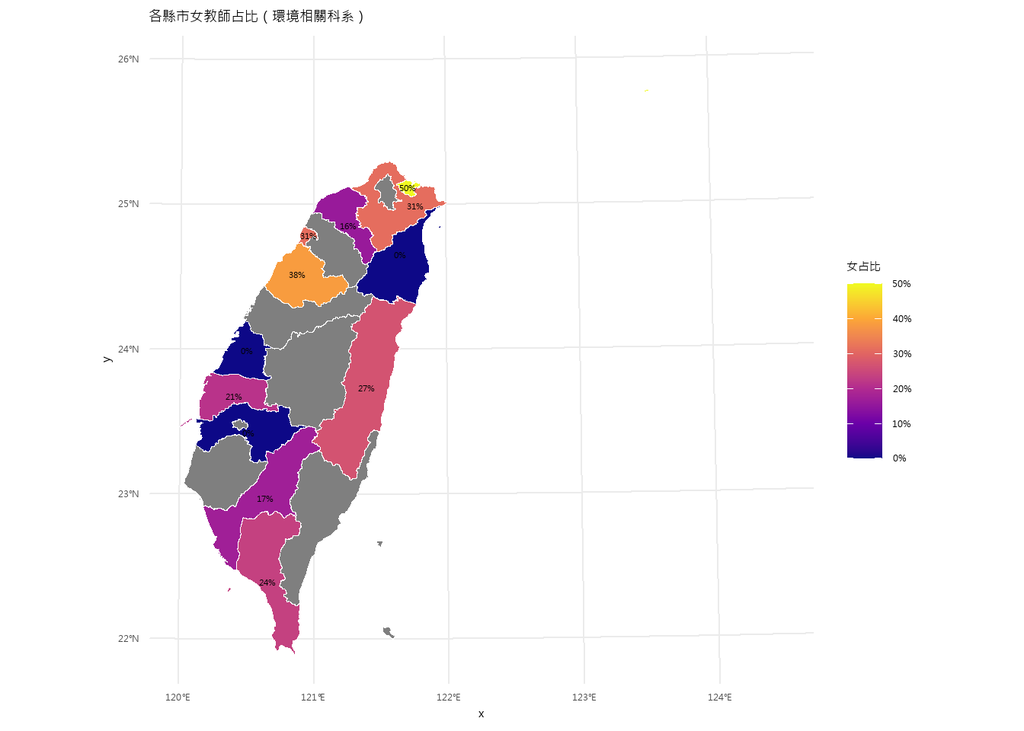

```r
library(scales)


# 字型支援
font_add("cw", "msjh.ttc")
showtext_auto()



# 3. 合併地圖與女教師占比
map_data <- taiwan_map %>%
  mutate(countyname = trimws(countyname)) %>%
  left_join(female_ratio_df, by = c("countyname" = "county"))

# 4. 畫地圖
ggplot(map_data) +
  geom_sf(aes(fill = female_ratio), color = "white") +
  geom_sf_text(aes(label = percent(female_ratio, accuracy = 1)),
               size = 3, family = "cw") +
  scale_fill_viridis_c(option = "plasma", labels = percent) +
  labs(
    title = "各縣市女教師占比（環境相關科系）",
    fill = "女占比"
  ) +
  theme_minimal(base_family = "cw")
```

```r
# 儲存為 PDF
ggsave("D:/200學業/210.1新聞所/新聞資訊分析資料/第十二周作業/女教師占比地圖.pdf",
       width = 8, height = 6, dpi = 300, device = cairo_pdf)
```

本圖展示 113 學年度全台各縣市環境相關科系中，女性教師佔所有教師人數的比例（女教師人數 / 總教師人數），藉此觀察性別在不同地區的分布情形。數據來源為教育部提供之統計資料，並依據「中華民國學科標準分類（第5次修正）」中所屬的環境學門與環境工程學類彙整而成。

地圖依縣市為單位，顏色越偏紫代表女教師占比越低，越偏黃則代表占比越高，並於各縣市標示實際百分比，顯示為灰色的地區則是缺乏資料。

備註：從 106 學年度（2017年）開始，統計資料依據最新版的《學科標準分類（第5次修正）》。環境相關科系代碼包括：052環境學門以及07121環境工程細學類，包含生物科技、環境工程、海洋等等；然而大氣、地質、地理等不算在其中。